# ReproducibleProject1

Joaquin Mariano Trinidad III

5/19/2019

## Introduction

It is now possible to collect a large amount of data about personal movement using activity monitoring devices such as a Fitbit, Nike Fuelband, or Jawbone Up. These type of devices are part of the “quantified self” movement - a group of enthusiasts who take measurements about themselves regularly to improve their health, to find patterns in their behavior, or because they are tech geeks. But these data remain under-utilized both because the raw data are hard to obtain and there is a lack of statistical methods and software for processing and interpreting the data.

This assignment makes use of data from a personal activity monitoring device. This device collects data at 5 minute intervals through out the day. The data consists of two months of data from an anonymous individual collected during the months of October and November, 2012 and include the number of steps taken in 5 minute intervals each day.

The data for this assignment can be downloaded from the course web site: * Dataset: [Activity monitoringdata](https://d396qusza40orc.cloudfront.net/repdata%2Fdata%2Factivity.zip)

The variables included in this data set are:

steps: Number of steps taken in a 5-minute interval (missing values are coded as NA????????)  
date: The date on which the measurement was taken in YYYY-MM-DD format  
interval: Identifier for the 5-minute interval in which measurement was taken  
The dataset is stored in a comma-separated-value (CSV) file and containing a total of 17,568 observations.

## Loading and preprocessing data

```r
url <- "https://d396qusza40orc.cloudfront.net/repdata%2Fdata%2Factivity.zip"
download.file(url, file.path(getwd(), "Activity.zip"))
unzip(zipfile = "Activity.zip")

library(dplyr)
library(ggplot2)
library(lubridate)
library(data.table)
```

## Reading data set into R environment

```r
activity <- data.table::fread("activity.csv")
```

# 1. Mean steps per day

## 1-1 Calculate the total number of steps taken per day

```r
dailysteps <- group_by(activity,date) %>%
        summarise(total_steps = sum(steps))
dailysteps$day <- seq(1:nrow(dailysteps))
```

## 1-2 Histogram of daily steps

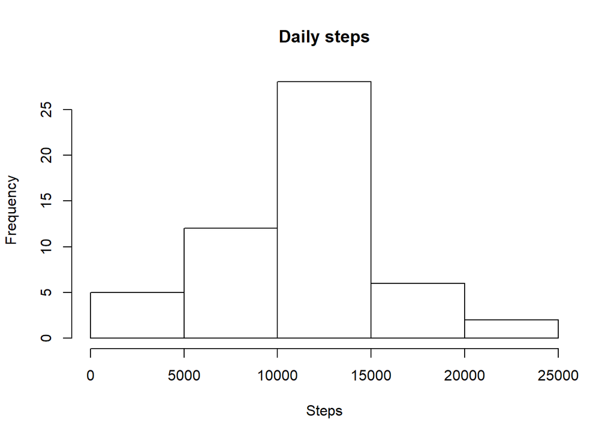

```r
hist(dailysteps$total_steps,xlab = "Steps",main = "Daily steps")
```

## 1-3 Mean and Median of total number of steps per day

```r
mean_steps <- mean(dailysteps$total_steps, na.rm = TRUE)
median_steps <- median(dailysteps$total_steps,na.rm = TRUE)
print(c("Median Steps",median_steps))
```

```
## [1] "Median Steps" "10765"
```

```r
print(c("Mean Steps",mean_steps))
```

```
## [1] "Mean Steps"       "10766.1886792453"
```

# 2. Average daily activity pattern

## 2-1 time-series plot of the 5 minute interval

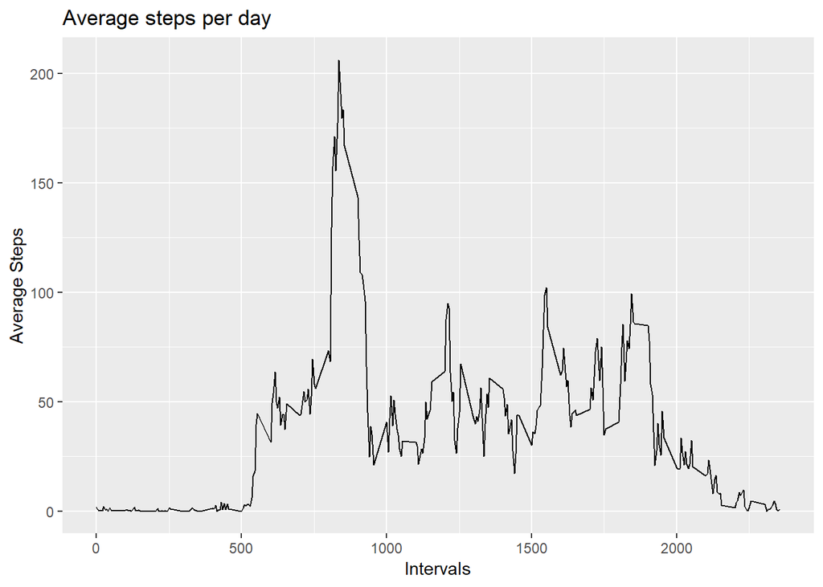

```r
tsdf <- group_by(activity,interval) %>%
        summarise(ave_steps = mean(steps,na.rm = TRUE))

b <- ggplot(tsdf,aes(x=interval, y=ave_steps))
        b + geom_line() + labs(title = "Average steps per day",y = "Average Steps",x="Intervals")
```

## 2-2 Which 5-minute interval contains max number of steps

```r
tsdf[tsdf$ave_steps == max(tsdf$ave_steps),"interval"]
```

```
## # A tibble: 1 x 1
##   interval
##      <int>
## 1      835
```

# 3. Inputting Missing Values

## 3-1 Number of missing values in the dataset

```r
activity[is.na(steps),.N]
```

```
## [1] 2304
```

```r
z <- activity
y <- inner_join(z,tsdf,by.x = z$interval,by.y = tsdf$interval)
NAdf <-y[is.na(y$steps),]
NAdf$steps <- NAdf$ave_steps
NotNAdf <- y[!is.na(y$steps),]
clean <- rbind(NotNAdf,NAdf) %>%
        select(steps,date,interval)
```

## 3-3 New data frame with missing values filled in using mean steps per interval

```r
write.csv(x=clean,file = "activityTIDY.csv")
```

## 3-4 Make a histogram total number of steps daily, calculate mean and median

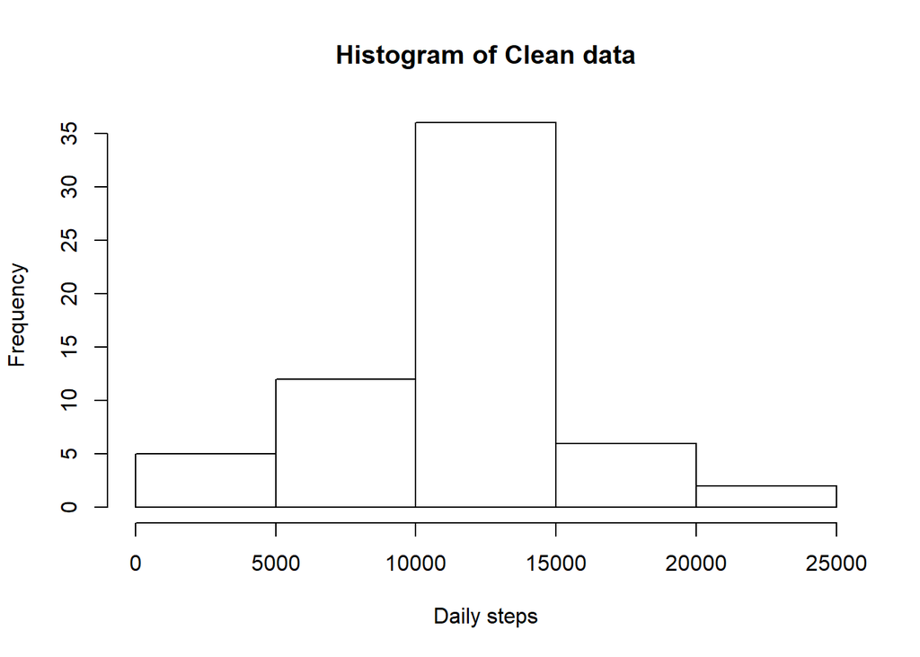

```r
# plot clean data
clean_daily <- group_by(clean,date) %>%
        summarise(daily_steps = sum(steps))
hist(clean_daily$daily_steps,xlab = "Daily steps",main = "Histogram of Clean data")
```

```r
# calculate mean and median
mean_daily <- mean(clean_daily$daily_steps)
median_daily <- median(clean_daily$daily_steps)
print(c(mean_daily,median_daily))
```

```
## [1] 10766.19 10766.19
```

# 4. Weekday patterns vs. Weekend patterns

## 4-1 Factor variable with two levels - “weekday” and “weekend”

```r
x <- clean
x$day <- wday(x$date)

weekend <- group_by(x,day) %>%
        subset(day==1| day == 7)
weekend$weekstatus <- "weekend"
weekend <-select(weekend,steps,date,interval,weekstatus)
weekdays <- group_by(x,day) %>%
        subset(day==2| day == 3 | day == 4 | day == 5 | day == 6)
weekdays$weekstatus <- "weekday"
weekdays <- select(weekdays,steps,date,interval,weekstatus)
finaldf<-rbind(weekdays,weekend)
```

## 4-2 Panel plot time series

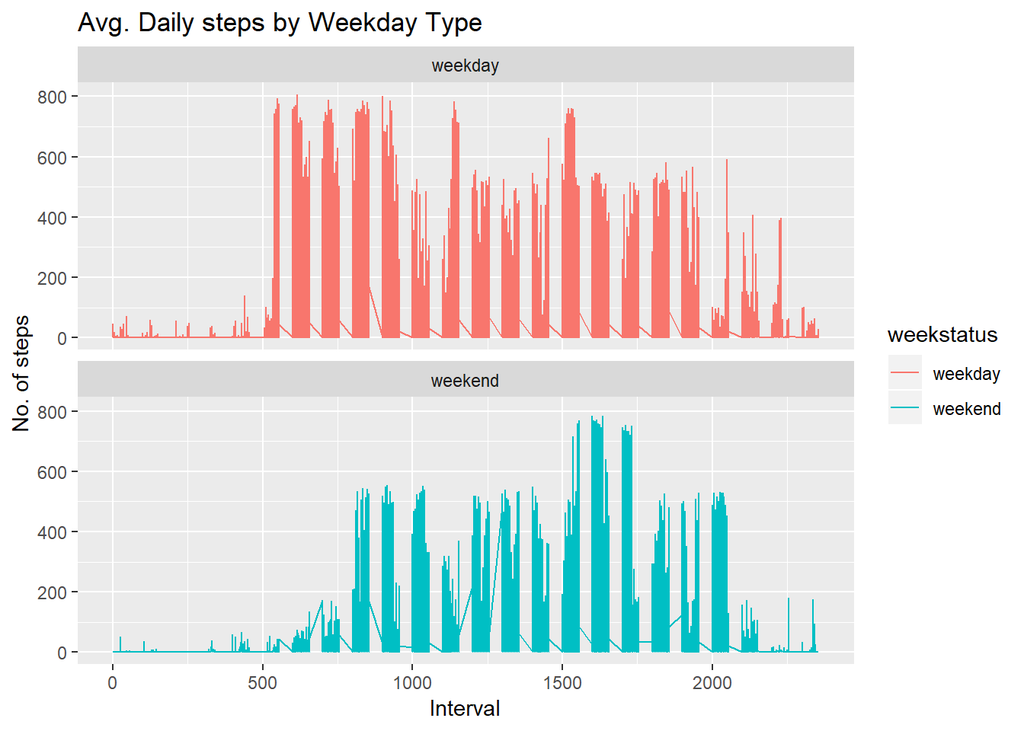

```r
f<-ggplot(finaldf,aes(x=interval,y=steps,color=weekstatus))
f+geom_line() + labs(title="Avg. Daily steps by Weekday Type",x = "Interval", y="No. of steps") + facet_wrap(~`weekstatus`,ncol = 1, nrow =2)
```